# Predicting Condominium Sale Prices

# Linear Regression Model for Boroughs in New York City Combined

Now that we’ve removed many multi-unit sales from the dataset, let’s generate a linear regression model for all New York City neighborhoods combined. As a reminder, we are predicting `sale_price` on the basis of `gross_square_feet`.

```r
NYC_condos_lm <- lm(sale_price ~ gross_square_feet, data = NYC_condos)
summary(NYC_condos_lm)
```

```
##
## Call:
## lm(formula = sale_price ~ gross_square_feet, data = NYC_condos)
##
## Residuals:
##       Min        1Q    Median        3Q       Max
## -19865368   -840026    156635    938585 140321290
##
## Coefficients:
##                     Estimate Std. Error t value Pr(>|t|)
## (Intercept)       -3.110e+06  5.709e+04  -54.47   <2e-16 ***
## gross_square_feet  4.462e+03  3.947e+01  113.04   <2e-16 ***
## ---
## Signif. codes:  0 '***' 0.001 '**' 0.01 '*' 0.05 '.' 0.1 ' ' 1
##
## Residual standard error: 2945000 on 7944 degrees of freedom
## Multiple R-squared:  0.6166, Adjusted R-squared:  0.6166
## F-statistic: 1.278e+04 on 1 and 7944 DF,  p-value: < 2.2e-16
```

How does this compare to the `NYC_condos_original` dataframe that includes multi-unit sales?

```r
NYC_condos_original_lm <- lm(sale_price ~ gross_square_feet, data = NYC_condos_original)
summary(NYC_condos_original_lm)
```

```
##
## Call:
## lm(formula = sale_price ~ gross_square_feet, data = NYC_condos_original)
##
## Residuals:
##       Min        1Q    Median        3Q       Max
## -79533546  -1211195   -860173   -251714 211550415
##
## Coefficients:
##                    Estimate Std. Error t value Pr(>|t|)
## (Intercept)       940683.39   57703.86   16.30   <2e-16 ***
## gross_square_feet   1192.72      19.43   61.39   <2e-16 ***
## ---
## Signif. codes:  0 '***' 0.001 '**' 0.01 '*' 0.05 '.' 0.1 ' ' 1
##
## Residual standard error: 4745000 on 8094 degrees of freedom
## Multiple R-squared:  0.3177, Adjusted R-squared:  0.3176
## F-statistic:  3769 on 1 and 8094 DF,  p-value: < 2.2e-16
```

## Comparison of linear modeling results

A bivariate linear regression of `sale_price` (price) explained by `gross_square_feet` (size) was performed on two different datasets containing condominium sale records for New York City. One dataset, `NYC_condos`, was cleaned to remove multi-unit sale records (where the same sale price is recorded for many units). The other dataset, `NYC_condos_original`, remained unaltered and contained all original sale records. In each case, the hypothesis is that there is a relationship between the size of a condominium (`gross_square_feet`) and the price (`sale_price`). We can declare there is a relationship between condominium size and price when the slope is sufficiently far from zero.

For each model, the t-statistic was high enough, and the p-value was low enough, to declare that there is, in fact, a relationship between `gross_square_feet` and `sale_price`. The t-statistic for the cleaned dataset (`NYC_condos`) was nearly double that of the original dataset (`NYC_condos_original`) at 113.04 versus 61.39. In each case the p-value was well below the 0.05 cutoff for significance meaning that it is extremely unlikely that the relationship between condominium size and sale price is due to random chance.

The confidence interval for the slope is [4384.254, 4538.999] for the `NYC_condos` dataset compared to only [1154.636, 1230.802] for the `NYC_condos_original` dataset. This difference can likely be attributed to the removal of many multi-million dollar sale records for smaller units which impacted price predictions in the original dataset. The measure for *lack of fit*, or residual standard error (RSE) was lower for the cleaned dataset at 2,945,000 compared to 4,745,000 for the original dataset. However, it must be noted that the `NYC_condos` is smaller than the `NYC_condos_original` by 150 observations. Finally, the R-squared, or the proportion of the variability in `sale_price` that can be explained by `gross_square_feet` is 0.6166 for the cleaned `NYC_condos`. This is nearly double the R-squared value estimated for the `NYC_condos_original` dataset at 0.3177.

Below is the updated scatterplot that uses the cleaned `NYC_condos` data. For the Brooklyn borough we are better able to see the spread of the data and how the trend line fits the data because we removed the $30 million outliers. The same is true for the Manhattan borough because the $200 million multi-unit sale was removed.

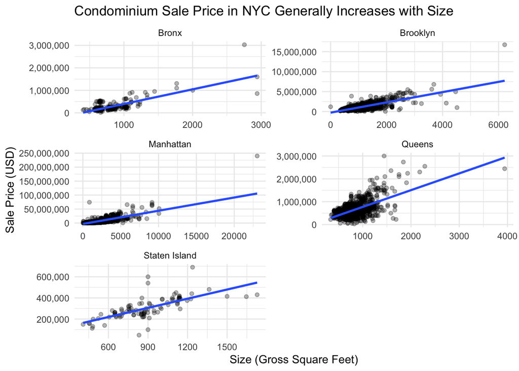

```r
ggplot(data = NYC_condos,
       aes(x = gross_square_feet, y = sale_price)) +
  geom_point(alpha = 0.3) +
  facet_wrap(~ borough, scales = "free", ncol = 2) +
  scale_y_continuous(labels = scales::comma) +
  geom_smooth(method = "lm", se = FALSE) +
  theme_minimal() +
  labs(title = "Condominium Sale Price in NYC Generally Increases with Size",
       x = "Size (Gross Square Feet)",
       y = "Sale Price (USD)")
```

# Linear Regression Models for each Borough - Coefficient Estimates

Now let’s apply the `broom` workflow to compare coefficient estimates across the five boroughs. The general workflow using broom and tidyverse tools to generate many models involves 4 steps:

1. Nest a dataframe by a categorical variable with the `nest()` function from the `tidyr` package - we will nest by `borough`.
2. Fit models to nested dataframes with the `map()` function from the `purrr` package.
3. Apply the `broom` functions `tidy()`, `augment()`, and/or `glance()` using each nested model - we’ll work with `tidy()` first.
4. Return a tidy dataframe with the `unnest()` function - this allows us to see the results.

```r
# Step 1: nest by the borough categorical variable
library(broom)
library(tidyr)
library(purrr)
NYC_nested <- NYC_condos %>%
  group_by(borough) %>%
  nest()
```

n the previous step, the `NYC_condos` dataframe was collapsed from 7,946 observations to only 5. The nesting process isolated the sale records for each borough into separate dataframes.

```r
# Inspect the format
print(NYC_nested)
```

```
## # A tibble: 5 × 2
## # Groups:   borough [5]
##   borough       data
##   <chr>         <list>
## 1 Bronx         <tibble [330 × 19]>
## 2 Brooklyn      <tibble [1,697 × 19]>
## 3 Manhattan     <tibble [4,819 × 19]>
## 4 Queens        <tibble [1,004 × 19]>
## 5 Staten Island <tibble [96 × 19]>
```

We can extract and inspect the values of any nested dataframe. Below is a look at the first six rows for Manhattan.

```r
# View first few rows for Manhattan
head(NYC_nested$data[[3]])
```

```
## # A tibble: 6 × 19
##   neighbor…¹ build…² tax_c…³ block   lot build…⁴ address apart…⁵ zip_c…⁶ resid…⁷
##   <chr>      <chr>   <chr>   <dbl> <dbl> <chr>   <chr>   <chr>     <dbl>   <dbl>
## 1 Alphabet … 13 Con… 2         373  1008 R4      324 Ea… 5B        10009       0
## 2 Alphabet … 13 Con… 2         373  1009 R4      324 Ea… 6A        10009       0
## 3 Alphabet … 13 Con… 2         375  1017 R4      754 Ea… 5A        10009       0
## 4 Alphabet … 13 Con… 2         378  1005 R4      399 Ea… 2C        10009       0
## 5 Alphabet … 13 Con… 2         384  1205 R4      310 Ea… 3C        10002       0
## 6 Alphabet … 13 Con… 2         384  1210 R4      310 Ea… 4B        10002       0
## # … with 9 more variables: commercial_units <dbl>, total_units <dbl>,
## #   land_square_feet <dbl>, gross_square_feet <dbl>, year_built <dbl>,
## #   tax_class_at_time_of_sale <dbl>, building_class_at_time_of_sale <chr>,
## #   sale_price <dbl>, sale_date <dttm>, and abbreviated variable names
## #   ¹neighborhood, ²building_class_category, ³tax_class_at_present,
## #   ⁴building_class_at_present, ⁵apartment_number, ⁶zip_code,
## #   ⁷residential_units
```

he next step in the process is to fit a linear model to each individual dataframe. What this means is that we are generating separate linear models for each borough individually.

```r
# Step 2: fit linear models to each borough, individually
NYC_coefficients <- NYC_condos %>%
  group_by(borough) %>%
  nest() %>%
  mutate(linear_model = map(.x = data,
                            .f = ~lm(sale_price ~ gross_square_feet,
                                     data = .)))
```

Taking a look at the data structure we see that we have a new list-column called `linear_model` that contains a linear model object for each borough.

```r
# Inspect the data structure
print(NYC_coefficients)
```

```
## # A tibble: 5 × 3
## # Groups:   borough [5]
##   borough       data                  linear_model
##   <chr>         <list>                <list>
## 1 Bronx         <tibble [330 × 19]>   <lm>
## 2 Brooklyn      <tibble [1,697 × 19]> <lm>
## 3 Manhattan     <tibble [4,819 × 19]> <lm>
## 4 Queens        <tibble [1,004 × 19]> <lm>
## 5 Staten Island <tibble [96 × 19]>    <lm>
```

We can view the linear modeling results for any one of the nested objects using the `summary()` function. Below are the linear regression statistics for Manhattan.

```r
# Verify model results for Manhattan
summary(NYC_coefficients$linear_model[[3]])
```

```
##
## Call:
## lm(formula = sale_price ~ gross_square_feet, data = .)
##
## Residuals:
##       Min        1Q    Median        3Q       Max
## -21128191  -1001860    224235   1103543 134333578
##
## Coefficients:
##                     Estimate Std. Error t value Pr(>|t|)
## (Intercept)       -3.254e+06  8.584e+04  -37.91   <2e-16 ***
## gross_square_feet  4.728e+03  5.178e+01   91.31   <2e-16 ***
## ---
## Signif. codes:  0 '***' 0.001 '**' 0.01 '*' 0.05 '.' 0.1 ' ' 1
##
## Residual standard error: 3588000 on 4817 degrees of freedom
## Multiple R-squared:  0.6338, Adjusted R-squared:  0.6337
## F-statistic:  8337 on 1 and 4817 DF,  p-value: < 2.2e-16
```

A quick look at the R-squared value for the Manhattan linear model indicates that `gross_square_feet` looks to be a fairly good single predictor of `sale_price`. Almost two-thirds of the variability with `sale_price` is explained by `gross_square_feet`.

The next step is to transform these linear model summary statistics into a tidy format.

```r
# Step 3: generate a tidy dataframe of coefficient estimates that includes confidence intervals
NYC_coefficients <- NYC_condos %>%
  group_by(borough) %>%
  nest() %>%
  mutate(linear_model = map(.x = data,
                            .f = ~lm(sale_price ~ gross_square_feet,
                                     data = .))) %>%
  mutate(tidy_coefficients = map(.x = linear_model,
                                 .f = tidy,
                                 conf.int = TRUE))
NYC_coefficients
```

```
## # A tibble: 5 × 4
## # Groups:   borough [5]
##   borough       data                  linear_model tidy_coefficients
##   <chr>         <list>                <list>       <list>
## 1 Bronx         <tibble [330 × 19]>   <lm>         <tibble [2 × 7]>
## 2 Brooklyn      <tibble [1,697 × 19]> <lm>         <tibble [2 × 7]>
## 3 Manhattan     <tibble [4,819 × 19]> <lm>         <tibble [2 × 7]>
## 4 Queens        <tibble [1,004 × 19]> <lm>         <tibble [2 × 7]>
## 5 Staten Island <tibble [96 × 19]>    <lm>         <tibble [2 × 7]>
```

Now we have a new variable called `tidy_coefficients` that contains tidy coefficient estimates for each of the five boroughs. These tidy statistics are currently stored in five separate dataframes. Below are the coefficient estimates for Manhattan.

```r
# Inspect the results for Manhattan
print(NYC_coefficients$tidy_coefficients[[3]])
```

```
## # A tibble: 2 × 7
##   term               estimate std.error statistic   p.value  conf.low conf.high
##   <chr>                 <dbl>     <dbl>     <dbl>     <dbl>     <dbl>     <dbl>
## 1 (Intercept)       -3253992.   85837.      -37.9 1.94e-275 -3422273. -3085712.
## 2 gross_square_feet     4728.      51.8      91.3 0             4626.     4829.
```

```r
# Step 4: Unnest to a tidy dataframe of coefficient estimates
NYC_coefficients_tidy <- NYC_coefficients %>%
  select(borough, tidy_coefficients) %>%
  unnest(cols = tidy_coefficients)
print(NYC_coefficients_tidy)
```

```
## # A tibble: 10 × 8
## # Groups:   borough [5]
##    borough       term          estim…¹ std.e…² stati…³   p.value conf.…⁴ conf.…⁵
##    <chr>         <chr>           <dbl>   <dbl>   <dbl>     <dbl>   <dbl>   <dbl>
##  1 Bronx         (Intercept)   -2.54e5 24668.   -10.3  9.89e- 22 -3.03e5 -2.05e5
##  2 Bronx         gross_square…  6.49e2    29.6   21.9  2.58e- 66  5.91e2  7.07e2
##  3 Brooklyn      (Intercept)   -2.72e5 34487.    -7.88 5.64e- 15 -3.40e5 -2.04e5
##  4 Brooklyn      gross_square…  1.29e3    29.7   43.2  1.06e-275  1.23e3  1.34e3
##  5 Manhattan     (Intercept)   -3.25e6 85837.   -37.9  1.94e-275 -3.42e6 -3.09e6
##  6 Manhattan     gross_square…  4.73e3    51.8   91.3  0          4.63e3  4.83e3
##  7 Queens        (Intercept)    3.99e4 28311.     1.41 1.59e-  1 -1.56e4  9.55e4
##  8 Queens        gross_square…  7.33e2    32.0   22.9  8.14e- 94  6.70e2  7.95e2
##  9 Staten Island (Intercept)    4.64e4 28256.     1.64 1.04e-  1 -9.67e3  1.03e5
## 10 Staten Island gross_square…  2.89e2    30.7    9.41 3.30e- 15  2.28e2  3.49e2
## # … with abbreviated variable names ¹estimate, ²std.error, ³statistic,
## #   ⁴conf.low, ⁵conf.high
```

We’re mainly interested in the slope which explains the change in y (sale price) for each unit change in x (square footage). We can filter for the slope estimate only as follows.

```r
# Filter to return the slope estimate only
NYC_slope <- NYC_coefficients_tidy %>%
  filter(term == "gross_square_feet") %>%
  arrange(estimate)
print(NYC_slope)
```

```
## # A tibble: 5 × 8
## # Groups:   borough [5]
##   borough       term           estim…¹ std.e…² stati…³   p.value conf.…⁴ conf.…⁵
##   <chr>         <chr>            <dbl>   <dbl>   <dbl>     <dbl>   <dbl>   <dbl>
## 1 Staten Island gross_square_…    289.    30.7    9.41 3.30e- 15    228.    349.
## 2 Bronx         gross_square_…    649.    29.6   21.9  2.58e- 66    591.    707.
## 3 Queens        gross_square_…    733.    32.0   22.9  8.14e- 94    670.    795.
## 4 Brooklyn      gross_square_…   1285.    29.7   43.2  1.06e-275   1227.   1344.
## 5 Manhattan     gross_square_…   4728.    51.8   91.3  0           4626.   4829.
## # … with abbreviated variable names ¹estimate, ²std.error, ³statistic,
## #   ⁴conf.low, ⁵conf.high
```

We’ve arranged the results in ascending order by the slope estimate. For each of the five boroughs, the t-statistic and p-value indicate that there is a relationship between `sale_price` and `gross_square_feet`. In Staten Island, an increase in square footage by one unit is estimated to increase the sale price by about $288, on average. In contrast, an increase in total square footage by one unit is estimated to result in an increase in sale price of about $4,728, on average.

# Linear Regression Models for each Borough - Regression Summary Statistics

Now we will apply the same workflow using `broom` tools to generate tidy regression summary statistics for each of the five boroughs. Below we follow the same process as we saw previously with the `tidy()` function, but instead we use the `glance()` function.

```r
# Generate a tidy dataframe of regression summary statistics
NYC_summary_stats <- NYC_condos %>%
  group_by(borough) %>%
  nest() %>%
  mutate(linear_model = map(.x = data,
                            .f = ~lm(sale_price ~ gross_square_feet,
                                     data = .))) %>%
  mutate(tidy_summary_stats = map(.x = linear_model,
                                  .f = glance))
print(NYC_summary_stats)
```

```
## # A tibble: 5 × 4
## # Groups:   borough [5]
##   borough       data                  linear_model tidy_summary_stats
##   <chr>         <list>                <list>       <list>
## 1 Bronx         <tibble [330 × 19]>   <lm>         <tibble [1 × 12]>
## 2 Brooklyn      <tibble [1,697 × 19]> <lm>         <tibble [1 × 12]>
## 3 Manhattan     <tibble [4,819 × 19]> <lm>         <tibble [1 × 12]>
## 4 Queens        <tibble [1,004 × 19]> <lm>         <tibble [1 × 12]>
## 5 Staten Island <tibble [96 × 19]>    <lm>         <tibble [1 × 12]>
```

```r
# Unnest to a tidy dataframe of
NYC_summary_stats_tidy <- NYC_summary_stats %>%
  select(borough, tidy_summary_stats) %>%
  unnest(cols = tidy_summary_stats) %>%
  arrange(r.squared)
print(NYC_summary_stats_tidy)
```

```
## # A tibble: 5 × 13
## # Groups:   borough [5]
##   borough   r.squ…¹ adj.r…²  sigma stati…³   p.value    df  logLik    AIC    BIC
##   <chr>       <dbl>   <dbl>  <dbl>   <dbl>     <dbl> <dbl>   <dbl>  <dbl>  <dbl>
## 1 Queens      0.344   0.343 2.80e5   525.  8.14e- 94     1 -14018. 2.80e4 2.81e4
## 2 Staten I…   0.485   0.480 7.35e4    88.6 3.30e- 15     1  -1211. 2.43e3 2.44e3
## 3 Brooklyn    0.524   0.524 5.65e5  1868.  1.06e-275     1 -24883. 4.98e4 4.98e4
## 4 Bronx       0.595   0.594 1.51e5   481.  2.58e- 66     1  -4404. 8.81e3 8.82e3
## 5 Manhattan   0.634   0.634 3.59e6  8337.  0             1 -79570. 1.59e5 1.59e5
## # … with 3 more variables: deviance <dbl>, df.residual <int>, nobs <int>, and
## #   abbreviated variable names ¹r.squared, ²adj.r.squared, ³statistic
```

These results will be summarized in our conclusion paragraph below.

# Conclusion

Our analysis showed that, in general, the `gross_square_feet` variable is useful for explaining, or estimating, `sale_price` for condominiums in New York City. We observed that removing multi-unit sales from the dataset increased model accuracy. With linear models generated for New York City as a whole, and with linear models generated for each borough individually, we observed in all cases that the t-statistic was high enough, and the p-value was low enough, to declare that there is a relationship between `gross_square_feet` and `sale_price`.

For the linear models that we generated for each individual borough, we observed a wide range in slope estimates. The slope estimate for Manhattan was much higher than the estimate for any of the other boroughs. We did not remove the record-setting $240 million property sale from the dataset, but future analysis should investigate the impacts that this single listing has on modeling results.